# Simulation Report

2021-11-30

## Simulation model

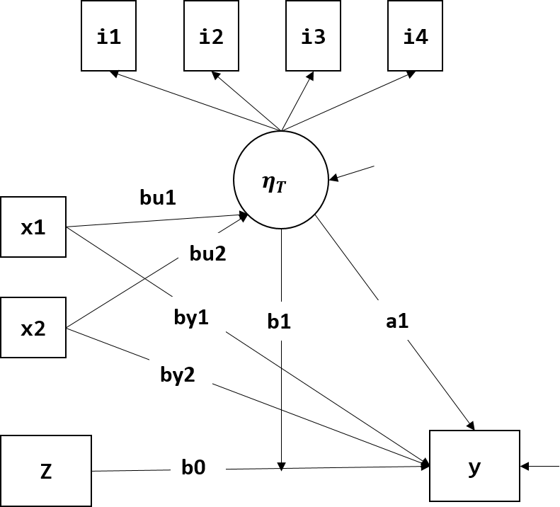

## Scaled version with incomplete data for latent variable models

Incomplete data means that the data for latent variable models has missingness (the default setting).

The problem is even with the scaled version; the estimated eta is sometimes negatively correlated with the true eta (see sem 7, for example). In that case, the parameter estimates regarding the eta (b1, bu1, bu2) show the opposite direction to the true parameters.

### sem

#### 1

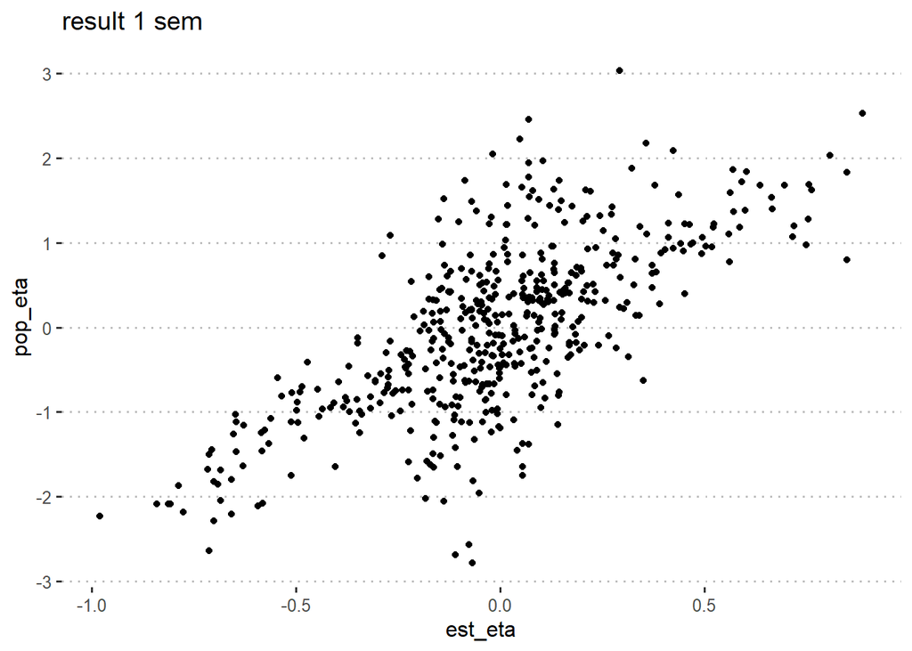

```
##           b00      b0       b1       a1     by1    by2    bu1     bu2
## true -0.02333 0.06180 -0.07527  0.18108 -0.3004 0.3100 0.2711 -0.3192
## est  -0.01098 0.05036  0.31422 -0.03476 -0.2817 0.2805 0.1119 -0.1169
```

#### 2

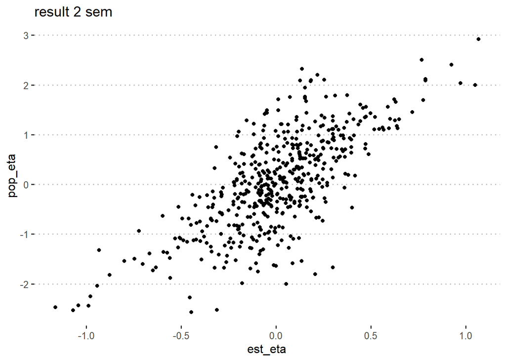

```
##          b00      b0      b1     a1     by1    by2    bu1      bu2
## true 0.06244 0.06896 -0.0682 0.2178 -0.2634 0.3201 0.3459 -0.26461
## est  0.07109 0.06448 -0.2508 0.7098 -0.2908 0.3277 0.1570 -0.09861
```

#### 3

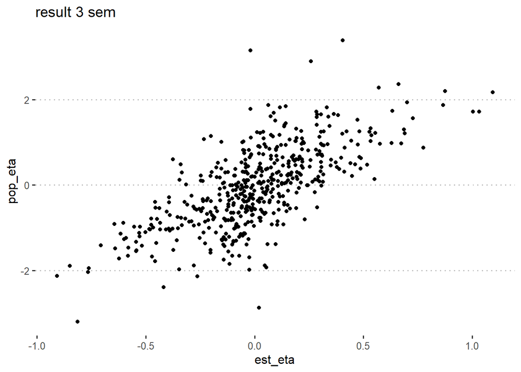

```
##          b00     b0      b1     a1     by1    by2    bu1     bu2
## true 0.03963 0.1239 -0.1064 0.2234 -0.3522 0.3771 0.3142 -0.2588
## est  0.02833 0.1255 -0.3090 0.4785 -0.3308 0.3699 0.1202 -0.1047
```

#### 4

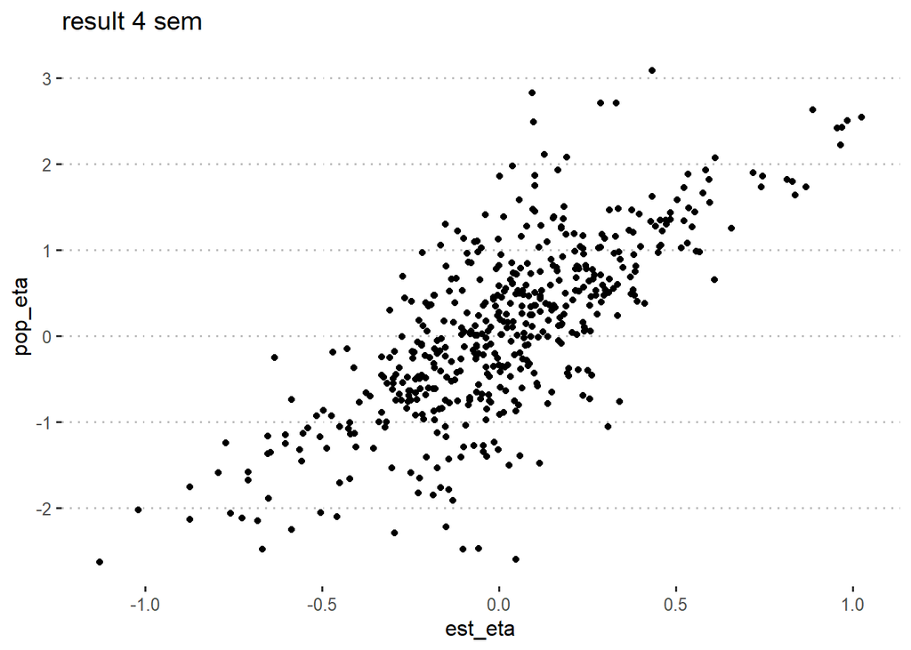

```
##           b00     b0      b1     a1     by1    by2    bu1     bu2
## true -0.06307 0.1381 -0.2443 0.2722 -0.2659 0.3864 0.3112 -0.3268
## est  -0.05342 0.1281 -0.7940 0.8519 -0.2603 0.3943 0.1035 -0.1402
```

#### 5

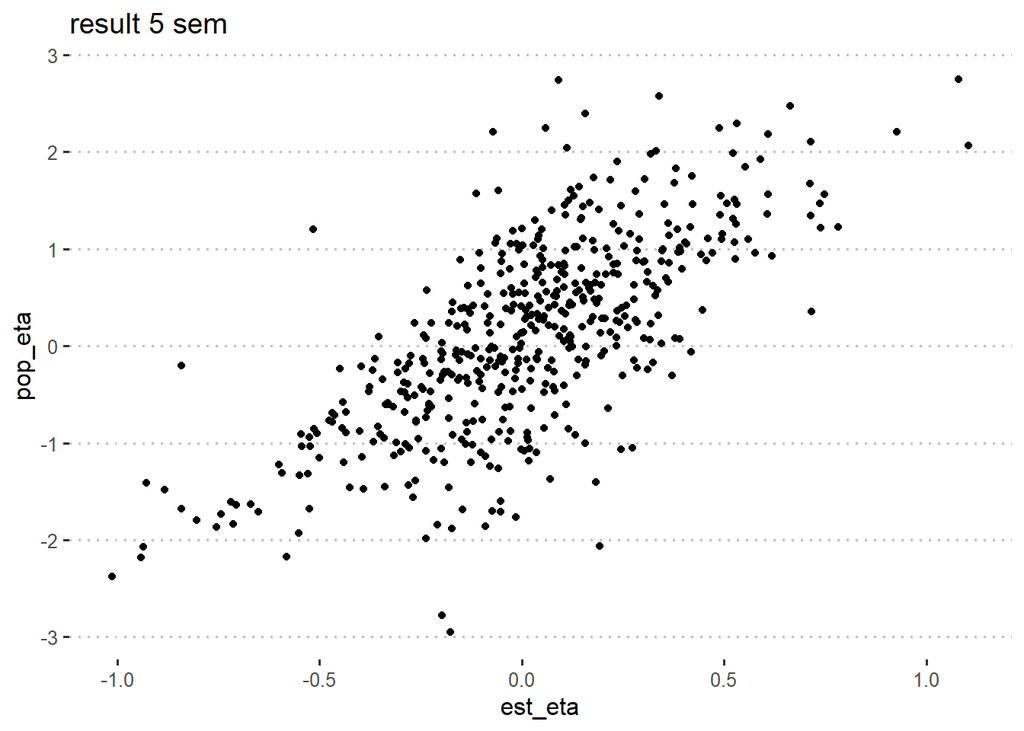

```
##          b00       b0       b1     a1     by1    by2    bu1     bu2
## true 0.07030 -0.01268 -0.08968 0.2452 -0.2537 0.3475 0.3496 -0.3088
## est  0.09537 -0.02843 -0.11986 0.5231 -0.2450 0.3606 0.1406 -0.1551
```

#### 6

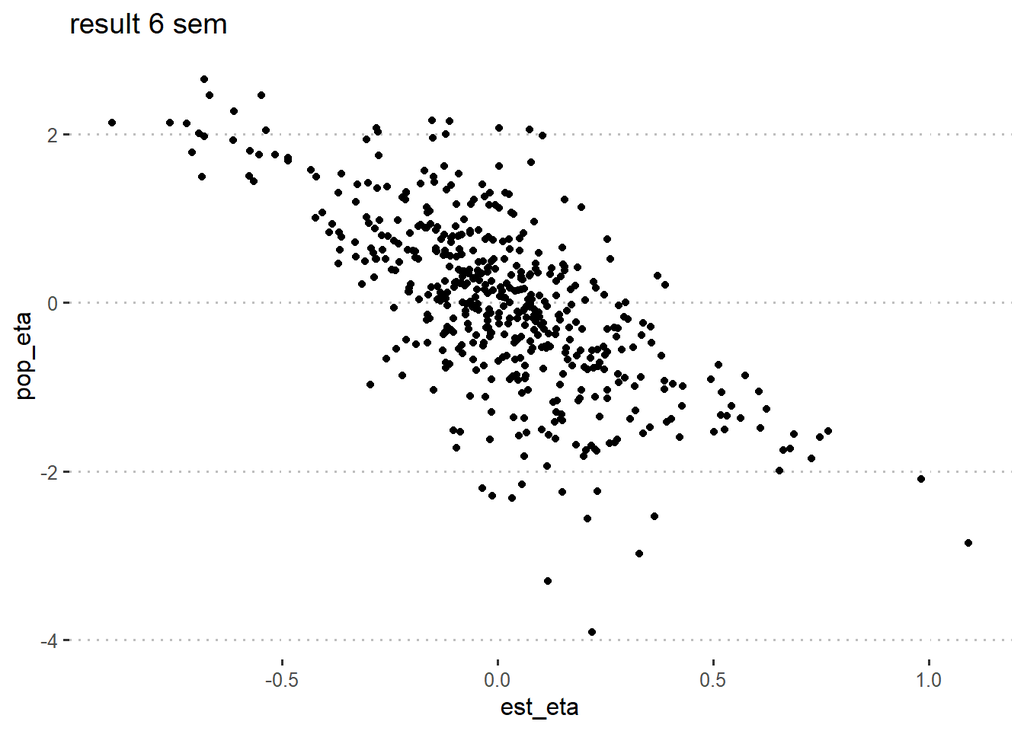

```
##          b00      b0      b1      a1     by1    by2     bu1      bu2
## true 0.07335 0.07594 -0.2183  0.2743 -0.3283 0.4184  0.3660 -0.27974
## est  0.04156 0.11540 -0.0748 -0.2146 -0.3038 0.3959 -0.1236  0.09771
```

#### 7

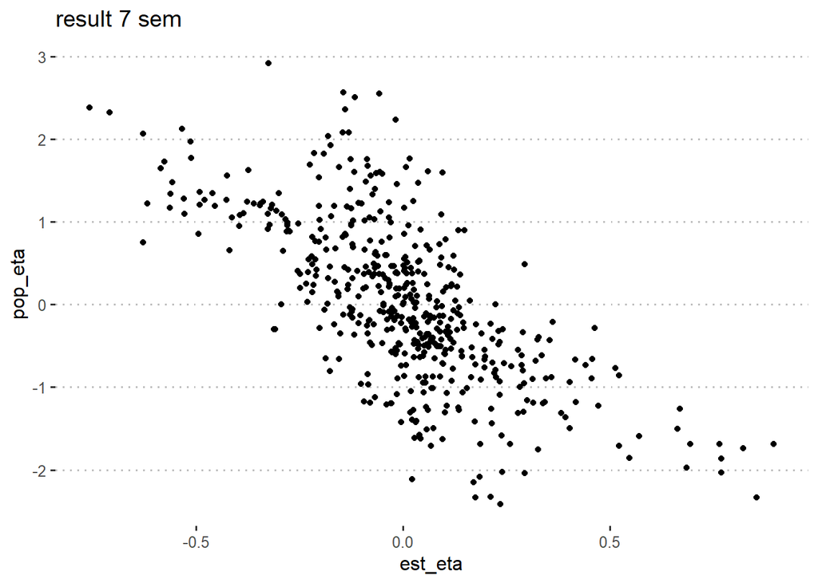

```
##          b00      b0       b1      a1     by1    by2      bu1      bu2
## true 0.06855 0.07799 -0.06508  0.2042 -0.3494 0.2878  0.29513 -0.26693
## est  0.06725 0.08221  0.07643 -0.4060 -0.3290 0.2568 -0.09104  0.05102
```

#### 8

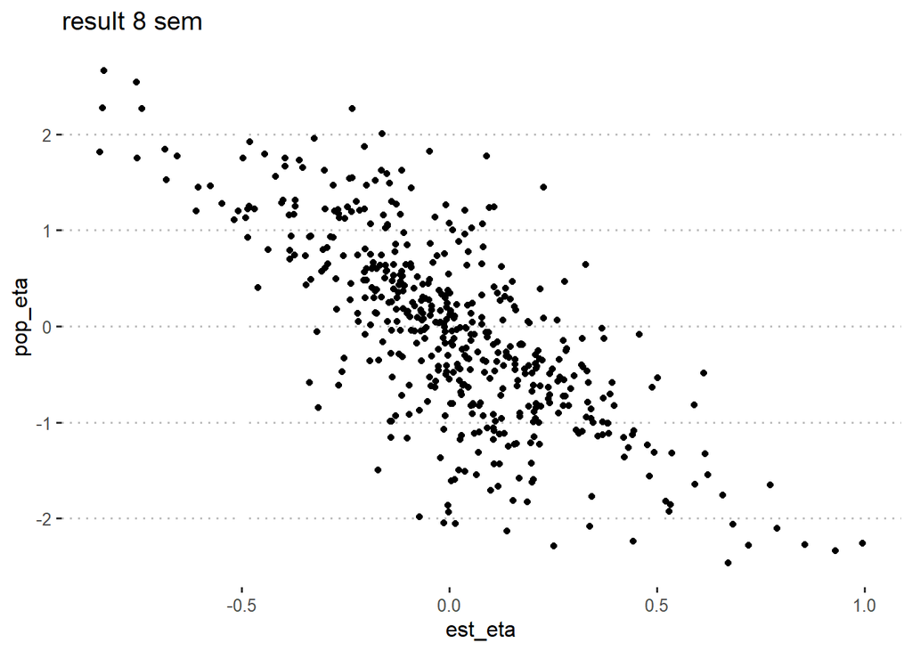

```
##           b00     b0      b1      a1     by1    by2     bu1     bu2
## true -0.08996 0.2969 -0.1524  0.2464 -0.3223 0.3005  0.2889 -0.3212
## est  -0.11353 0.3224  0.4711 -0.7191 -0.3241 0.2957 -0.1045  0.1067
```

#### 9

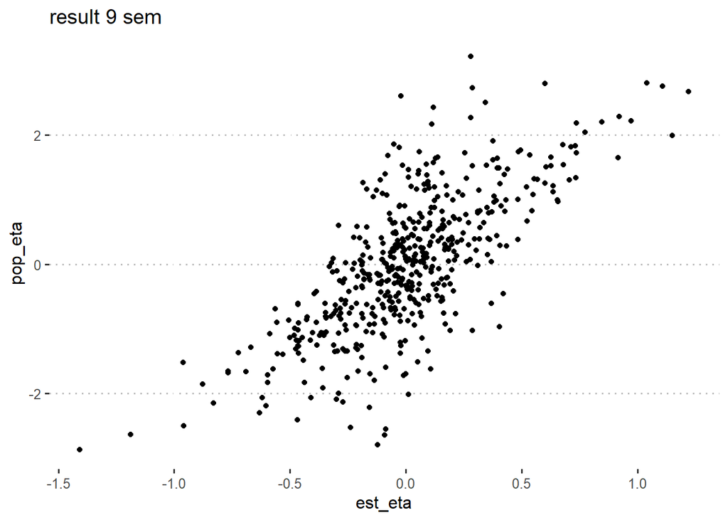

```
##          b00     b0       b1     a1     by1    by2    bu1     bu2
## true 0.03595 0.1433 -0.12366 0.2062 -0.3566 0.2821 0.3421 -0.3815
## est  0.03992 0.1392  0.06112 0.0914 -0.3305 0.2482 0.1419 -0.1559
```

#### 10

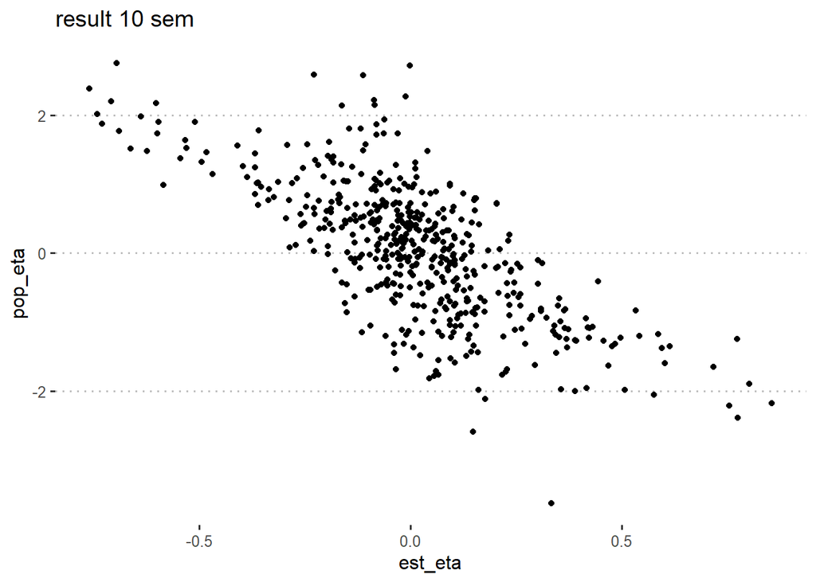

```
##           b00      b0       b1      a1     by1    by2      bu1      bu2
## true 0.005196 0.01267 -0.02678  0.1379 -0.3167 0.2881  0.33021 -0.34071
## est  0.012216 0.01913 -0.17682 -0.1526 -0.3016 0.2684 -0.09577  0.08905
```

### 2PL

#### 1

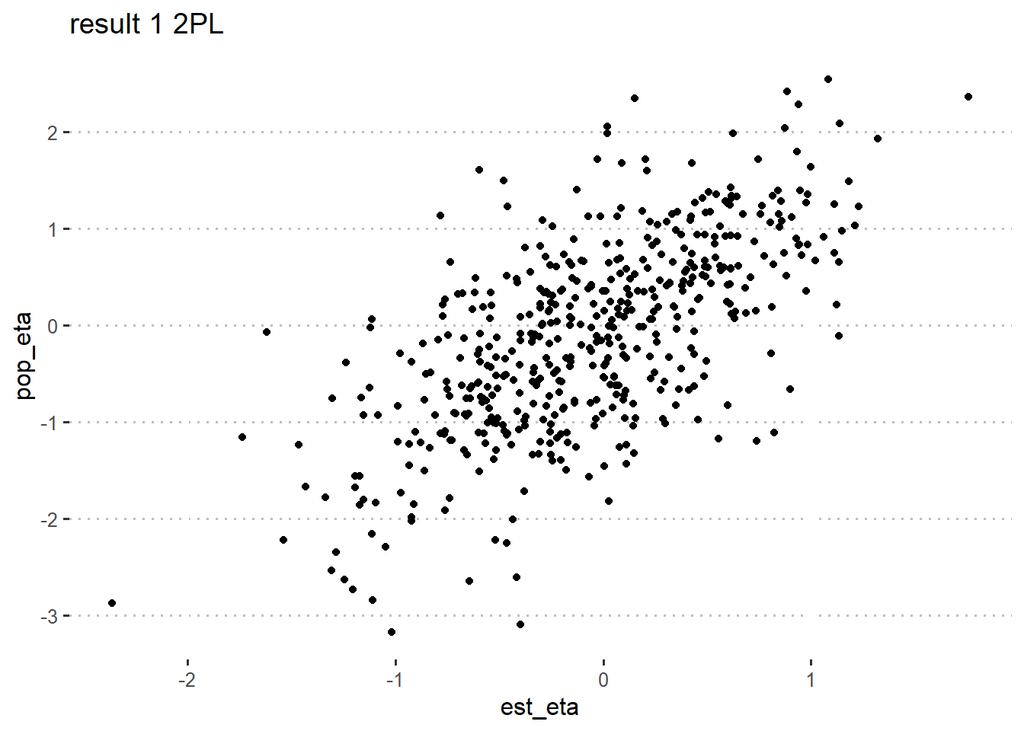

```
##            b00     b0      b1      a1     by1    by2    bu1     bu2
## true -0.005369 0.0931 0.03396 0.12289 -0.3289 0.3057 0.3580 -0.4483
## est  -0.021643 0.1232 0.16484 0.06363 -0.3310 0.2986 0.3676 -0.3882
```

#### 2

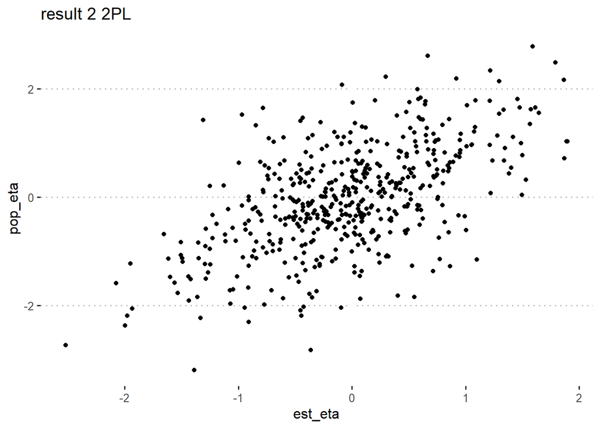

```
##           b00     b0        b1     a1     by1    by2    bu1     bu2
## true -0.01999 0.1100 -0.004899 0.1803 -0.3570 0.2850 0.2768 -0.3346
## est  -0.02027 0.1059 -0.058750 0.3732 -0.3912 0.3955 0.2461 -0.5014
```

#### 3

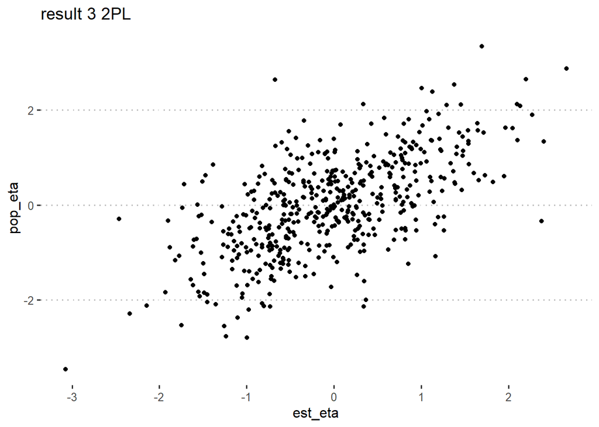

```
##         b00       b0      b1     a1     by1    by2    bu1     bu2
## true 0.1262 -0.03446 -0.2553 0.2979 -0.2752 0.3131 0.3208 -0.3618
## est  0.1326 -0.03209 -0.4732 0.4979 -0.3071 0.3521 0.3238 -0.3712
```

#### 4

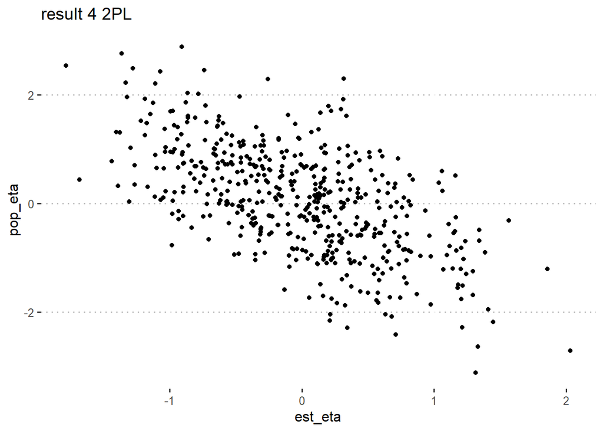

```
##          b00     b0      b1      a1     by1    by2     bu1     bu2
## true 0.02952 0.1555 0.06443  0.1468 -0.2876 0.2588  0.2749 -0.3295
## est  0.03734 0.1529 0.18302 -0.4101 -0.3282 0.3167 -0.2935  0.3589
```

#### 5

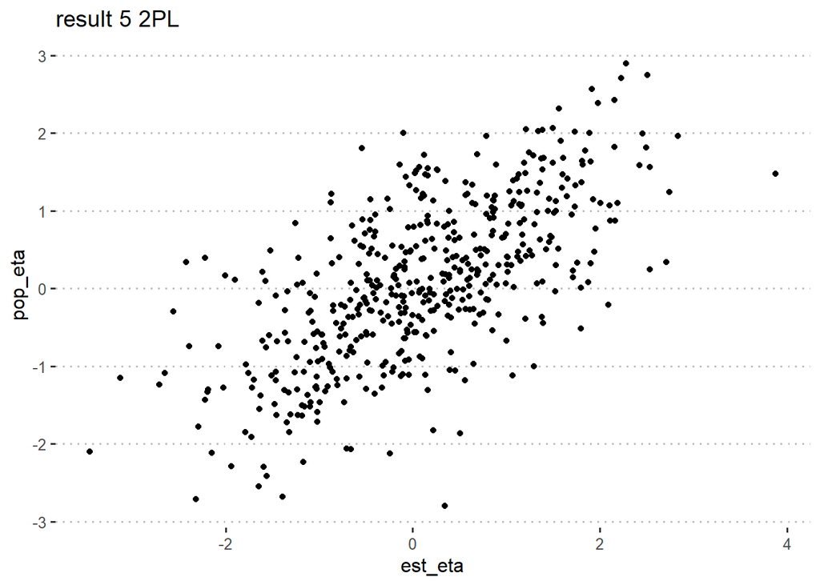

```
##           b00     b0       b1     a1     by1    by2    bu1     bu2
## true 0.004816 0.1317 -0.21611 0.2664 -0.3672 0.2846 0.3744 -0.3788
## est  0.019218 0.1097 -0.08172 0.1874 -0.3769 0.3491 0.4448 -0.8326
```

#### 6

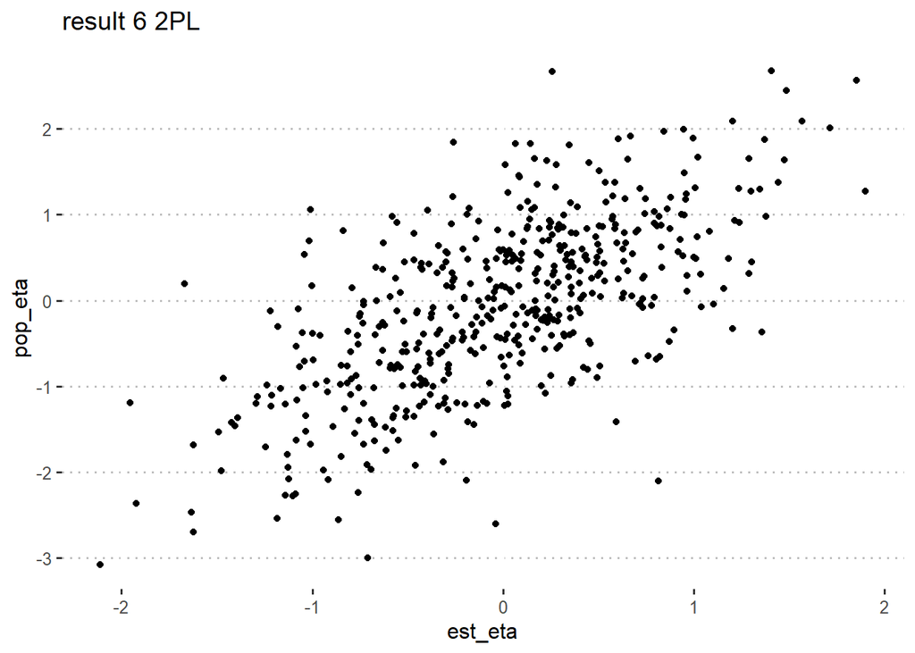

```
##            b00    b0      b1     a1     by1    by2    bu1     bu2
## true -0.003995 0.168 0.04593 0.1875 -0.3703 0.4203 0.3974 -0.3173
## est  -0.017075 0.175 0.07509 0.2574 -0.4342 0.4267 0.5064 -0.2537
```

#### 7

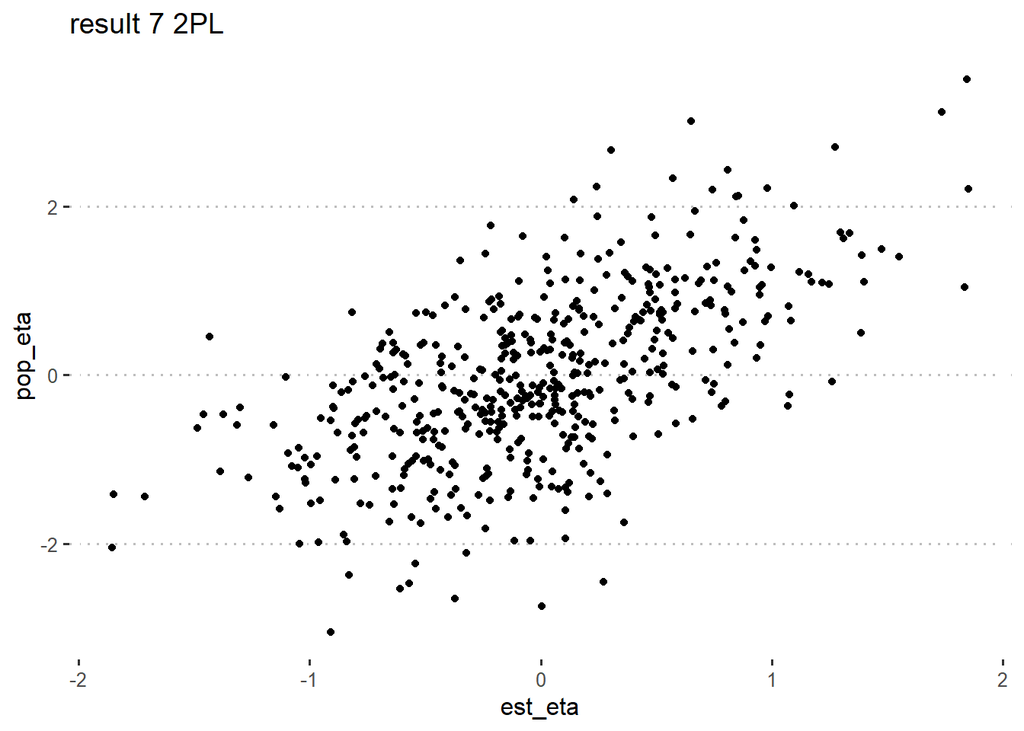

```
##           b00     b0       b1      a1     by1    by2    bu1     bu2
## true -0.01224 0.1728 0.004121 0.20269 -0.3768 0.2816 0.2660 -0.3367
## est  -0.03228 0.1996 0.051630 0.08513 -0.3576 0.2376 0.3068 -0.2364
```

#### 8

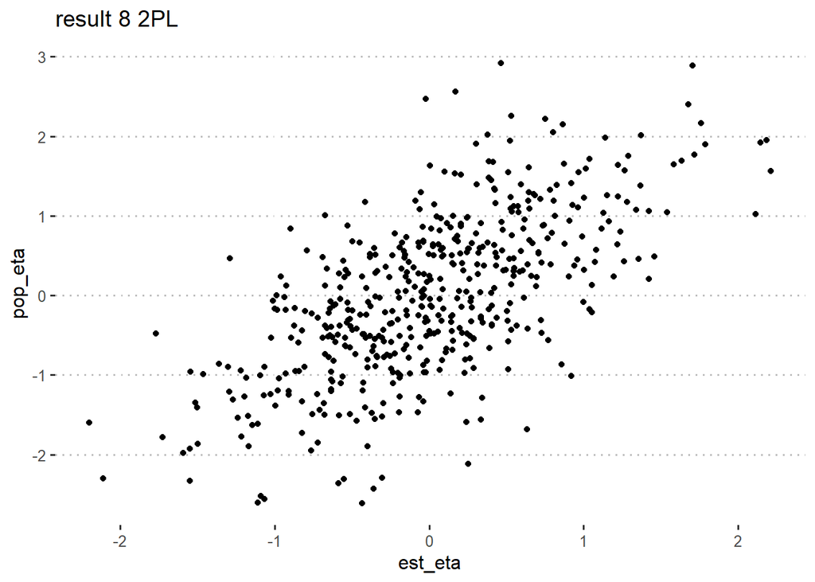

```
##            b00     b0       b1     a1     by1    by2    bu1     bu2
## true -0.009211 0.1784 -0.04136 0.1747 -0.3038 0.3590 0.3418 -0.2771
## est   0.007628 0.1462 -0.01742 0.1389 -0.2971 0.3487 0.3561 -0.2639
```

#### 9

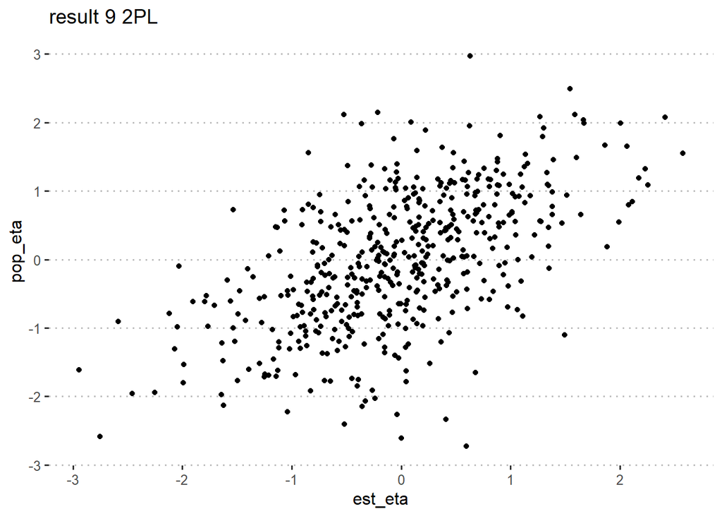

```
##           b00     b0       b1       a1     by1    by2    bu1     bu2
## true -0.06556 0.1859 -0.04853  0.23438 -0.3221 0.3296 0.2873 -0.3255
## est  -0.06151 0.1803  0.14147 -0.09075 -0.2501 0.2584 0.5181 -0.3637
```

#### 10

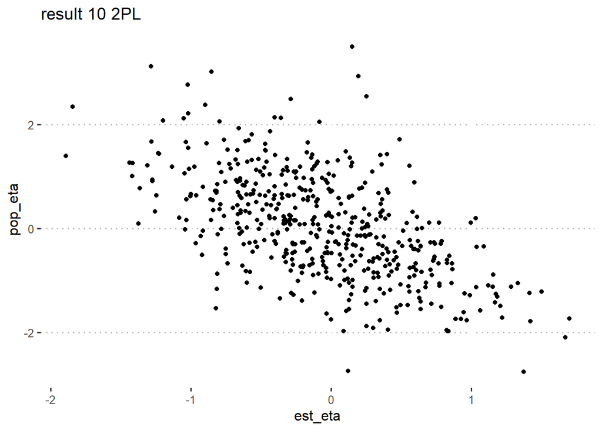

```
##         b00       b0       b1      a1     by1    by2     bu1     bu2
## true 0.1170 -0.03502  0.02795 0.15928 -0.3454 0.3465  0.2818 -0.3281
## est  0.1239 -0.06377 -0.30689 0.05658 -0.3326 0.3262 -0.3196  0.3552
```

### GPCM

#### 1

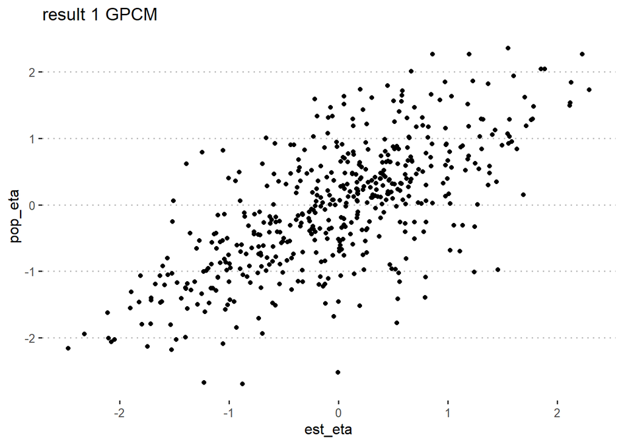

```
##           b00     b0      b1     a1     by1    by2    bu1     bu2
## true -0.06995 0.1314 -0.1653 0.3340 -0.3135 0.3127 0.3220 -0.2269
## est  -0.07357 0.1298 -0.4105 0.6132 -0.3519 0.3290 0.3097 -0.1911
```

#### 2

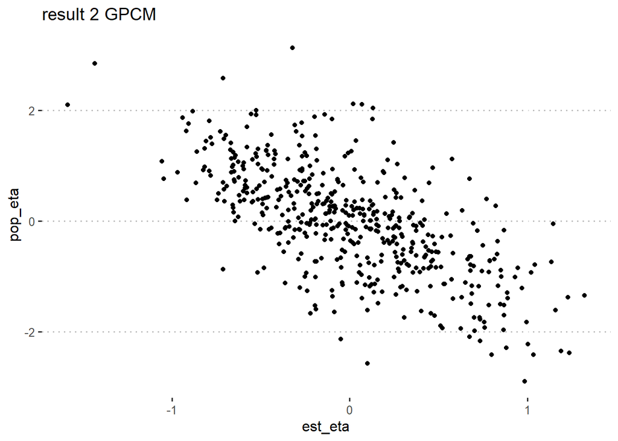

```
##           b00     b0      b1      a1     by1    by2     bu1     bu2
## true  0.01098 0.1245 0.02844  0.1299 -0.3850 0.2883  0.3209 -0.3370
## est  -0.02468 0.1806 0.30577 -0.6283 -0.4514 0.3552 -0.2219  0.2297
```

#### 3

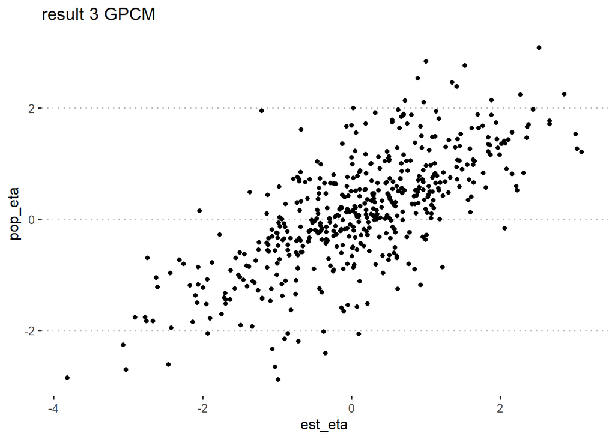

```
##          b00      b0       b1      a1     by1    by2    bu1     bu2
## true 0.07923 0.05149 -0.02809 0.28884 -0.4170 0.4139 0.3452 -0.3366
## est  0.11556 0.02349  0.10392 0.05641 -0.3878 0.3705 0.5112 -0.5263
```

#### 4

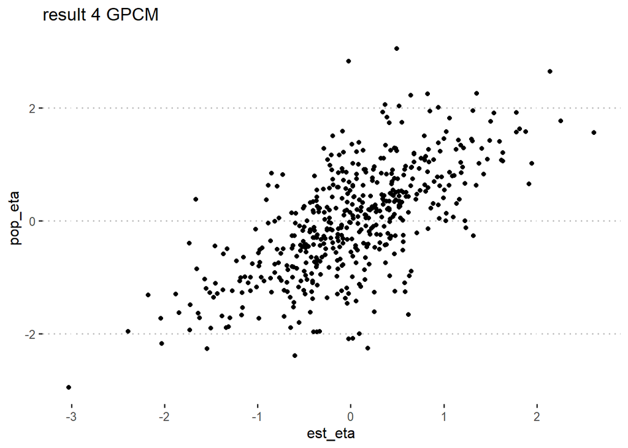

```
##           b00     b0       b1      a1     by1    by2    bu1    bu2
## true -0.01502 0.1591 -0.04238  0.2001 -0.2809 0.2548 0.3047 -0.336
## est  -0.02600 0.1580  0.22426 -0.1563 -0.2068 0.1804 0.3374 -0.281
```

#### 5

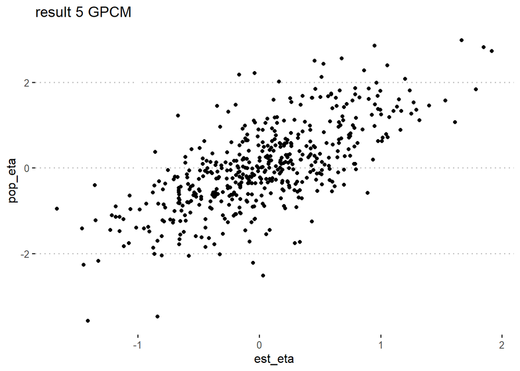

```
##          b00      b0       b1     a1     by1    by2    bu1     bu2
## true 0.01446 0.05931 -0.00446 0.1679 -0.3651 0.3314 0.3572 -0.3319
## est  0.02496 0.03258 -0.20595 0.3976 -0.3950 0.3561 0.3118 -0.2721
```

#### 6

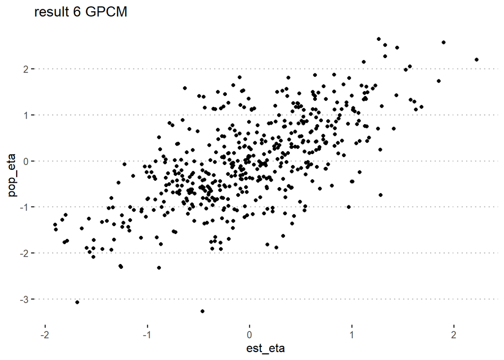

```
##          b00       b0       b1     a1     by1    by2    bu1     bu2
## true 0.03860 -0.07419 -0.04299 0.3128 -0.2952 0.3860 0.2590 -0.3266
## est  0.02939 -0.05673 -0.18069 0.5269 -0.3680 0.3715 0.3284 -0.2183
```

#### 7

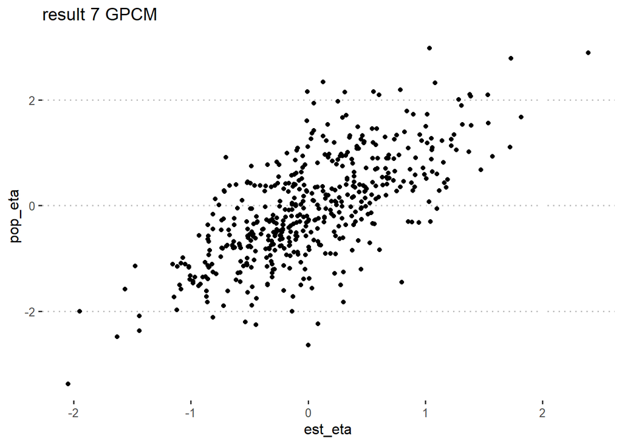

```
##           b00     b0      b1      a1     by1    by2    bu1     bu2
## true -0.04463 0.1794 0.02941 0.15619 -0.2999 0.2913 0.3543 -0.3491
## est  -0.04243 0.1403 0.07235 0.09512 -0.2918 0.2634 0.3810 -0.2526
```

#### 8

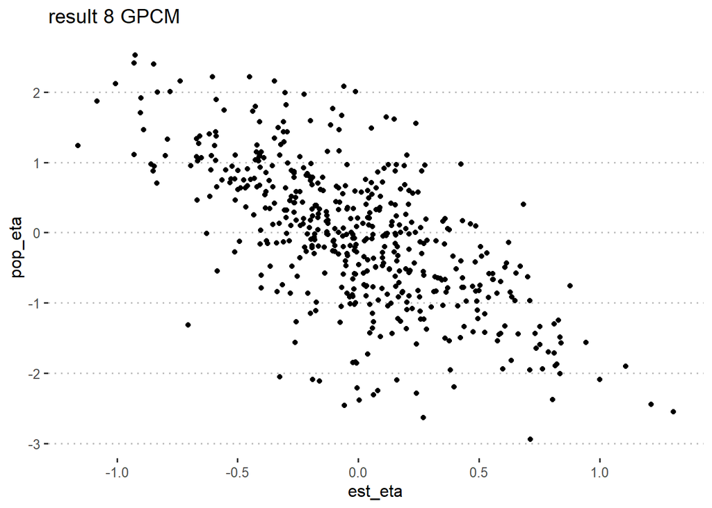

```
##            b00      b0       b1       a1     by1    by2     bu1     bu2
## true -0.003667 0.07932 -0.07948  0.22665 -0.3723 0.3612  0.3606 -0.3453
## est  -0.024170 0.09242 -0.16677 -0.07392 -0.3382 0.3286 -0.2478  0.1931
```

#### 9

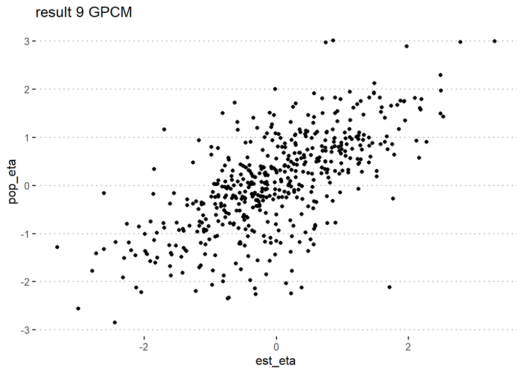

```
##          b00       b0       b1      a1     by1    by2    bu1     bu2
## true 0.09046 -0.07287 -0.03659 0.27725 -0.3262 0.3061 0.3249 -0.2910
## est  0.09686 -0.05220  0.07971 0.02544 -0.2765 0.2525 0.6219 -0.3616
```

#### 10

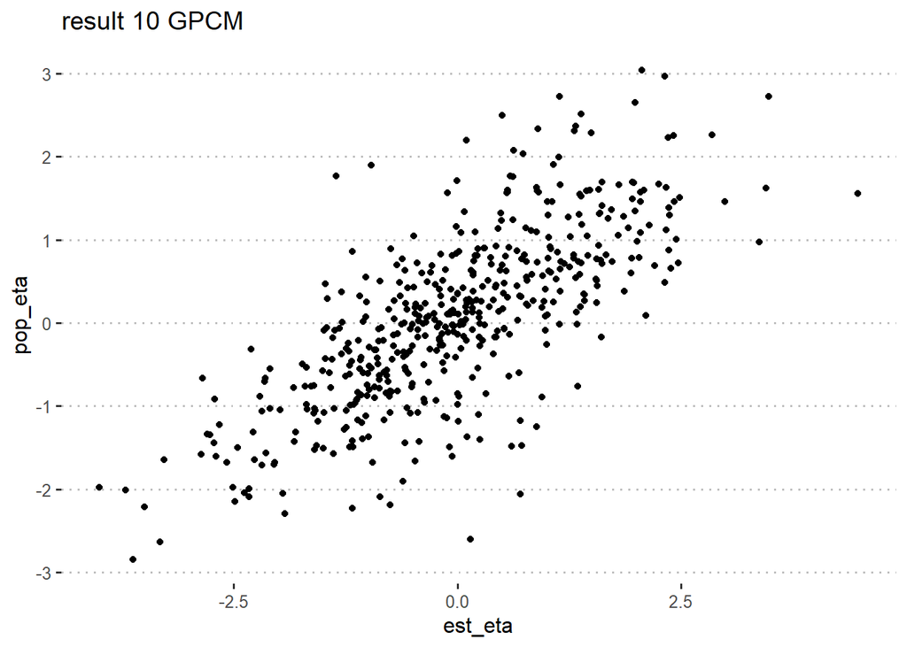

```
##           b00     b0       b1      a1     by1    by2    bu1     bu2
## true -0.05653 0.2646 -0.06782 0.22123 -0.3011 0.3340 0.3757 -0.2929
## est  -0.03168 0.2509  0.02405 0.08094 -0.2975 0.3081 0.6420 -0.4518
```